# TAD_second_clean

### Summary of the meeting on 9/6/2018 @Noble's lab

#### Most important issues:

**Issue 1**: The logistic regression underperformed, compared to the weighted sum of charges.  
Accuracy was used as the objective function during the optimization but roc_auc was used for validation.  
**Potential Solution**: change the objective function to roc_auc.

**Issue 2**: We have to overcome the bias towards total charges and be able to analyze the distribution of charges and/or other features.

- analyze prediction=f(charge) for the library, the positive or negative sets and for the human and yeast proteom.
- Use packages sent to me by Jacob to analyze NN and other type of models.
- try with 3-mers
- try NN with physicochemical properties only

predictions using 1 dense layer

#### Other important things discussed in the meeting

```python
## Import libraries and functions
%pylab inline
import seaborn as sns
import scipy, sklearn
import os,sys
import warnings
warnings.filterwarnings('ignore')
from second_library import *
from scipy.stats import spearmanr
from sklearn.metrics import roc_auc_score, roc_curve, auc
from physical_properties import properties

start, end = "\033[1m", "\033[0;0m" # this is to print bold

# physical properties
properties = properties.drop('pI', axis=1) # It includes information about the main chain that is not relevant here.
properties['volume2'] = properties['volume2'] - 60.1
properties['VdW'] = properties['VdW'] - 48

# load new data
positives = open_fastas('ARG3_O1_O2_clustered_rescored.fasta_bin14_threshold10.0_37923positives.fasta')
negatives = open_fastas('ARG3_O1_O2_clustered_rescored.fasta_bg_37923negatives.fasta')
positives['TAD']=1
negatives['TAD']=0
new_data = pd.concat([pd.DataFrame(i) for i in [positives, negatives]], axis=0)

# calculate aa frequencies per sample.
for i in aa:
    new_data[i] = [seq.count(i) / 30. for seq in new_data.index]

# indices to split data into train, test, val
np.random.seed=0
idx_new_data = np.arange(new_data.shape[0])
np.random.shuffle(idx_new_data)

# split_data
new_classification20 = split_data(idx_new_data, new_data, aa, 'TAD')

print('\t\t\tAUC'+"\t\t rs")
for prop in properties.columns:
    df = new_classification20[4].dot(properties.loc[aa, prop])
    auc_score = roc_auc_score(new_classification20[5], df)
    auc_score = [auc_score if auc_score>=0.5 else 1-auc_score][0]
    spearman = spearmanr(new_classification20[5], df)
    print('-'*50+'\n'+start+'{:23}'.format(prop)+end+'{:.2f}\t\t{:.2f}'.format(auc_score, spearman[0]))
```

```
			AUC		 rs
--------------------------------------------------
mass                   0.56		0.10
--------------------------------------------------
volume1                0.60		0.17
--------------------------------------------------
volume2                0.61		0.18
--------------------------------------------------
hydrophobicity1        0.70		0.35
--------------------------------------------------
hydrophobicity2        0.58		0.15
--------------------------------------------------
charge                 0.93		-0.75
--------------------------------------------------
VdW                    0.53		0.05
```

### Issue 1:

The objective function used by default in sklearn's logistic regression_cv is accuracy. I can change it to roc_auc and I should get ~0.94 (or 0.06). C values are the inverse of $\lambda$. Too small Cs are very strict. Here higher values are allowed (smaller $\lambda$s).

```python
from sklearn.linear_model import LogisticRegressionCV
from sklearn.metrics import make_scorer

model0 = LogisticRegressionCV(Cs = np.linspace(1e-4,1e-2, 40)) # default scoring with accuracy
model0.fit(new_classification20[0], new_classification20[1])
model0B= LogisticRegressionCV(Cs = np.linspace(1e-2, 10, 50)) # More relaxed regularization...
model0B.fit(new_classification20[0],new_classification20[1])
model1 = LogisticRegressionCV(Cs = np.linspace(1e-4, 10, 50), scoring=make_scorer(roc_auc_score), penalty='l1', solver='saga')
model1.fit(new_classification20[0], new_classification20[1])
model2 = LogisticRegressionCV(Cs = np.linspace(1e-4, 10, 50), scoring=make_scorer(roc_auc_score)) # default ridge
model2.fit(new_classification20[0], new_classification20[1])
y_hat0 = model0.predict(new_classification20[4])
y_hat0B= model0B.predict(new_classification20[4])
y_hat1 = model1.predict(new_classification20[4])
y_hat2 = model2.predict(new_classification20[4])

print(start+'logistic_regression_aminoacids'+end)
print('model0 (accuracy for training), roc_auc = {:.3f}'.format(roc_auc_score(new_classification20[5], y_hat0)))
print('model0 with less strict regularization allowed, roc_auc = {:.3f}'.format(roc_auc_score(new_classification20[5], y_hat0B)))
print('model1 (auc for training and penalty="L1"), roc_auc = {:.3f}'.format(roc_auc_score(new_classification20[5], y_hat1)))
print('model2 (auc for training and penalty="L2"), roc_auc = {:.3f}'.format(roc_auc_score(new_classification20[5], y_hat2)))

X = new_classification20[4].dot(properties.loc[aa, 'charge'])
y = new_classification20[5]
print(start+'weighted (charges) sum of aminoacids'+end)
print('roc_auc = {:.3f}'.format(1 - roc_auc_score(y,X)))
```

```
logistic_regression_aminoacids
model0 (accuracy for training), roc_auc = 0.878
model0 with less strict regularization allowed, roc_auc = 0.909
model1 (auc for training and penalty="L1"), roc_auc = 0.911
model2 (auc for training and penalty="L2"), roc_auc = 0.911
weighted (charges) sum of aminoacids
roc_auc = 0.940
```

1. I was using too strict regularization $\lambda$s.
2. Now values are closer to the weighted sum of amino-acid frequencies using charges as weights.
3. Using accuracy or roc_auc for training, the model performs the same. **BUT** not as good as weighted sum of charges.

What are the coefficients of the logistic regression model?

```python
coefs = dict(zip(aa, model2.coef_[0]))
sorted(coefs.items(), key=lambda x:x[1])
```

```
[('R', -31.72380681639397),
 ('K', -25.03468436590221),
 ('H', -13.332330716260108),
 ('Q', -9.228710925926983),
 ('T', -9.01063097240676),
 ('P', -7.821612873960177),
 ('S', -7.150513776255424),
 ('A', -5.717605676290595),
 ('G', -4.889187983968964),
 ('V', -1.7506889012528615),
 ('N', -1.0977026330961615),
 ('C', 3.333644202727001),
 ('M', 4.481997324462562),
 ('I', 4.6388668814689815),
 ('L', 8.292054075083634),
 ('Y', 9.158804407040018),
 ('F', 19.35155064625295),
 ('E', 19.99409917077385),
 ('D', 22.120178707721415),
 ('W', 25.353755845779098)]
```

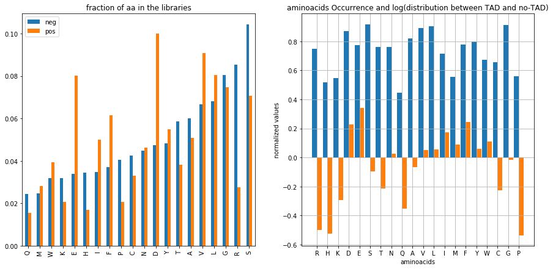

```python
# indices of positives and negatives in the training set
id_plus = new_classification20[1]==1
id_minus = new_classification20[1]==0

k,v = [], []
for i in aa:
    total = new_classification20[0][:,aa.index(i)].mean()
    negat = new_classification20[0][id_minus, aa.index(i)].mean()
    posit = new_classification20[0][id_plus, aa.index(i)].mean()
    k.append(i)
    v.append([total, negat, posit])

df = pd.DataFrame(v, index=k, columns=['total','neg','pos']).sort_values('neg')
df['logFC'] = np.log(df.pos / df.neg)
plt.figure(figsize=(15,7))
ax = plt.subplot(121)
df.drop(['logFC','total'], axis=1).plot.bar(ax=ax)
plt.title('fraction of aa in the libraries')


def count_occurrence(aminoacid):
    ids=[]
    for i in new_classification20[0]:
        if i[aa.index(aminoacid)]>0: ids.append(1)
        else: ids.append(0)
    ids = np.array(ids)
    a = np.sum(ids[id_plus])
    b = np.sum(ids[id_minus])
    return(a+b, np.log(a/b))

k,v = [],[]
for i in aa:
    occ = count_occurrence(i)
    k.append(i)
    occ = (occ[0] / new_classification20[0].shape[0], occ[1])
    v.append(occ)

# stack bars
w=0.45
ax = plt.subplot(122); ax.set_title('aminoacids Occurrence and log(distribution between TAD and no-TAD)')
ax.set_xticks(np.arange(20))
ax.bar(np.arange(20)-w/2, np.array(v)[:,0], width=w, label='')
ax.bar(np.arange(20)+w/2, np.array(v)[:,1], width=w)
ax.set_xticklabels(k);
ax.grid()
ax.set_xlabel('aminoacids'); ax.set_ylabel('normalized values');
```

#### Summary issue 1:

Logistic regression is still underperforming but we might not be interested in optimizing it further. Charges seem to be a major factor in classifying TADs but aminoacid sequences have more to tell.

### Is charge in our libraries and in each of our sets (positive and negative) distributed the same as in the [human](https://www.uniprot.org/proteomes/UP000005640) or [yeast](https://downloads.yeastgenome.org/curation/calculated_protein_info/protein_properties.tab) proteomes?

```python
## yeast
yeast = pd.read_csv('https://downloads.yeastgenome.org/curation/calculated_protein_info/protein_properties.tab', delimiter='\t', index_col=0)
yeast = yeast[['Ala', 'Cys', 'Asp', 'Glu', 'Phe', 'Gly', 'His', 'Ile', 'Lys',
               'Leu','Met', 'Asn', 'Pro', 'Gln', 'Arg', 'Ser', 'Thr', 'Val', 'Trp', 'Tyr']]
yeast.columns = ['A','C','D','E','F','G','H','I','K','L','M','N','P','Q','R','S','T','V','W','Y']
yeast['total'] = yeast.sum(axis=1)

## Human
import gzip
with gzip.open('./uniprot-proteome%3AUP000005640+AND+%28proteomecomponent%3A%22Chromosome+1%22+OR+--.fasta.gz', 'rb') as f:
    human = f.read().decode('utf-8')

k,v, tmp_k, tmp_v, ID = [],[],[],[], False
for i in human:
    if i== '>':
        header=True
        # fill the values ONLY after there is a KEY!
        if len(tmp_k)>0 and len(tmp_v)>0:
            k.append(''.join(tmp_k))
            v.append(''.join([i for i in tmp_v if i!='\n']))
        tmp_k, tmp_v = [], []

    if header:
        if i=='|':
            if not ID:
                ID = True
                continue
            else: ID = False
        if ID: tmp_k.append(i)
        if i =='\n': header=False
    if not header: tmp_v.append(i)

human = pd.DataFrame([i.strip() for i in k], index=[i.strip('\n').strip('>') for i in v], columns=['id'])

for i in aa:
    human[i] = [seq.count(i) *1.0/ len(seq) for seq in human.index]
    yeast[i] = yeast[i] / yeast['total']
```

```
charge distributions
```

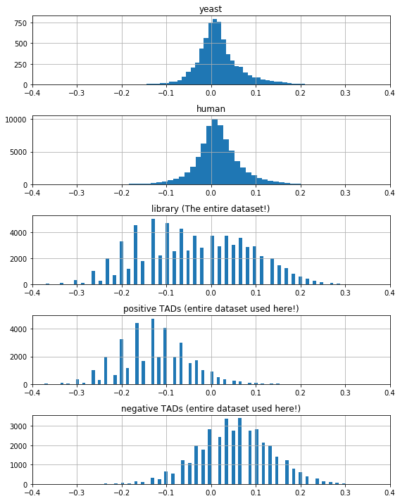

```python
charges_yeast = yeast[aa].values.dot(properties.loc[aa, 'charge'])
charges_human = human[aa].values.dot(properties.loc[aa, 'charge'])
charges_library = new_data[aa].values.dot(properties.loc[aa,'charge'])
charges_positives = new_data.loc[new_data['TAD']==1, aa].values.dot(properties.loc[aa,'charge'])
charges_negatives = new_data.loc[new_data['TAD']==0, aa].values.dot(properties.loc[aa, 'charge'])

print('charge distributions')
plt.figure(figsize=(8,10))
plt.subplot(511)
plt.hist(charges_yeast, bins=100); xlim(-0.4,0.4); plt.title('yeast'); plt.grid()
plt.subplot(512)
plt.hist(charges_human, bins=100); xlim(-0.4,0.4); plt.title('human'); plt.grid()
plt.subplot(513)
plt.hist(charges_library, bins=100); xlim(-0.4,0.4); plt.title('library (The entire dataset!)'); plt.grid()
plt.subplot(514)
plt.hist(charges_positives, bins=100); xlim(-0.4,0.4); plt.title('positive TADs (entire dataset used here!)'); plt.grid()
plt.subplot(515)
plt.hist(charges_negatives, bins=100); xlim(-0.4,0.4); plt.title('negative TADs (entire dataset used here!)'); plt.grid()
plt.tight_layout()
```

Human and yeast proteomes have very similar distribution of net charges (normalized by length) and around zero.  
The different distribution of *our non-natural* library, seems reasonable to me. Also, it might happend that there are boundaries of normalized net-charge of a protein and beyound these boundaries the proteins can't fold or even transcribe or translate?  
1- Why do values of charge from the library look discrete?  
2- positive set seems to be more negatively charged compared to human and yeast proteomes.

### Is there a correlation between predictions and net charges?

```
roc_auc: 0.06042742130435713
rs:      -0.7616064905298354
```

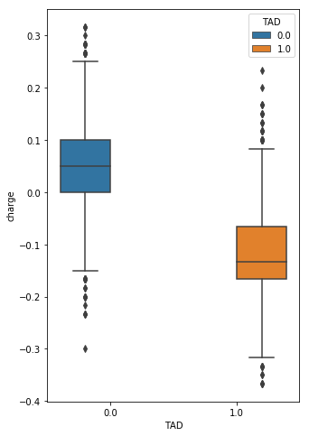

```python
proba = model2.predict_proba(new_classification20[4])[:,0]
charge = new_classification20[4].dot(properties.loc[aa,'charge'])

import seaborn as sns
plt.figure(figsize=(5,8))
df = pd.DataFrame(np.vstack([charge, new_classification20[5]]).T)
df.columns=['charge','TAD']
sns.boxplot(data=df, x='TAD', y='charge', hue='TAD')
print('roc_auc: '+ str(roc_auc_score(new_classification20[5], charge)))
print('rs:      '+ str(spearmanr(new_classification20[5], charge)[0]))
```

Reasonable. Charge is important.

### Do logistic regression model predictions (of TADs) in human and yeast proteomes correlate to charge?

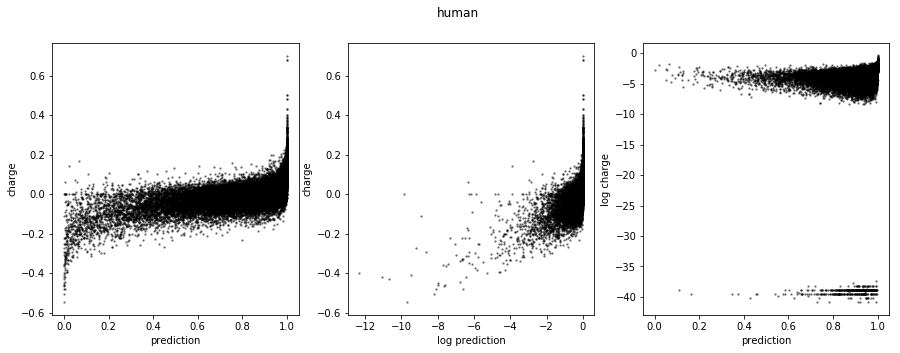

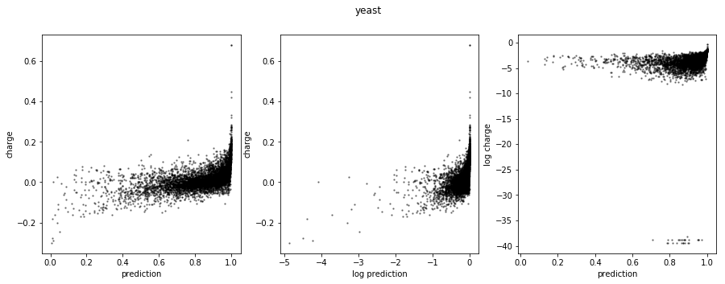

```python
plt.figure(figsize(15,5))
proba = model2.predict_proba(human[aa])[:,0]
charges =  human[aa].dot(properties.loc[aa,'charge'])
plt.subplot(131); plt.suptitle('human')
plt.scatter(proba, charges, s=2, c='k', alpha=0.4); plt.xlabel('prediction'); plt.ylabel('charge')
plt.subplot(132)
plt.scatter(np.log(proba), charges, s=2, c='k', alpha=0.4); plt.xlabel('log prediction'); plt.ylabel('charge')
plt.subplot(133)
plt.scatter(proba, np.log(charges), s=2, c='k', alpha=0.4); plt.xlabel('prediction'); plt.ylabel('log charge')
plt.figure(figsize=(15,5))
proba = model2.predict_proba(yeast[aa])[:,0]
charges = yeast[aa].dot(properties.loc[aa, 'charge'])
plt.subplot(131); plt.suptitle('yeast')
plt.scatter(proba, charges, s=2, c='k', alpha=0.4); plt.xlabel('prediction'); plt.ylabel('charge')
plt.subplot(132)
plt.scatter(np.log(proba), charges, s=2, c='k', alpha=0.4); plt.xlabel('log prediction'); plt.ylabel('charge')
plt.subplot(133)
plt.scatter(proba, np.log(charges), s=2, c='k', alpha=0.4); plt.xlabel('prediction'); plt.ylabel('log charge');
```

I don't believe that most proteins from humans and yeast are TADs...  
We can't base the predictions on charges alone.

### Neural Networks models

```python
from keras.models import Sequential
from keras.layers import Dense, Conv1D, Conv2D, Flatten, LSTM, Dropout, AveragePooling2D
from keras.callbacks import EarlyStopping
from tqdm import tqdm
import keras.backend as K
import itertools


# Generate the data with one hot encoding for single positions and even though I am going to test
# convolutional networks, I will also test the 2-mers.

# produce the ohe for the new_data
singles = new_data.index
singles = np.array([one_hot_encode(i) for i in singles]).reshape(singles.shape[0],600)
print(singles.shape)

# join ohe with scores or labels
ohe_data = pd.DataFrame(singles, index=new_data.index)
ohe_data = pd.concat([ohe_data, new_data.TAD],axis=1)

# split data
deep_classification = split_data(idx_new_data, ohe_data, np.arange(0,600), 'TAD')
```

```
(75846, 600)
```

#### How do Dense networks perform on sequence alone?

```
45it [13:57, 18.62s/it]
```

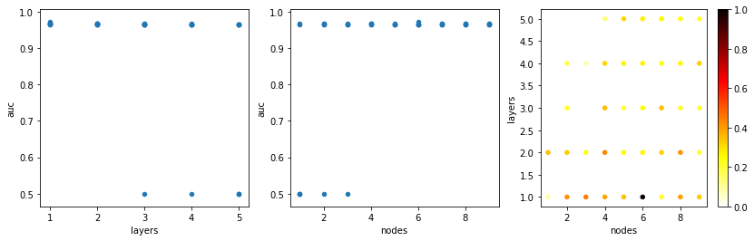

```python
callback = EarlyStopping(patience=1)
num_layers, num_nodes = range(1,6), np.arange(1,10) #5,30,5)

corrs = []

for nlayers, nnodes in tqdm(itertools.product(num_layers, num_nodes)):
    np.random.seed=0

    K.clear_session()
    model = Sequential()
    model.add(Dense(nnodes, activation='relu', input_shape=(600,)))

    for i in range(nlayers-1):
        model.add(Dense(nnodes, activation='relu'))

    model.add(Dense(1, activation='sigmoid'))
    model.compile(optimizer='adam', loss='binary_crossentropy', metrics=['accuracy'])
    model.fit(deep_classification[0], deep_classification[1],
              epochs=100,
              validation_split=0.1,
              callbacks=[callback],
              verbose=0)

    y_pred = model.predict(deep_classification[4])
    AUC = roc_auc_score(deep_classification[5], y_pred)
    corrs.append([nlayers, nnodes, model.count_params(), AUC])

corrs = np.array(corrs);
df = pd.DataFrame(corrs, columns=['layers','nodes','parameters','auc']).sort_values('auc', ascending=False)

sz = df.auc.values
m, M = sz[sz>0.5].min(), sz.max()
sz = (sz - m) / (M-m)
sz[sz<0] = 0
# Plot results
f, ax = plt.subplots(1,3, figsize=(14,4))
df.plot.scatter(x='layers', y='auc', ax=ax[0])
df.plot.scatter(x='nodes', y='auc', ax=ax[1])
df.plot.scatter(x='nodes', y='layers', ax=ax[2], c=sz, cmap='hot_r')
```

#### How do a NN model optimzed for aminoacid sequences, correlate with charges?

```
rs:      -0.7511408200485828
roc_auc: 0.06638653638136308
```

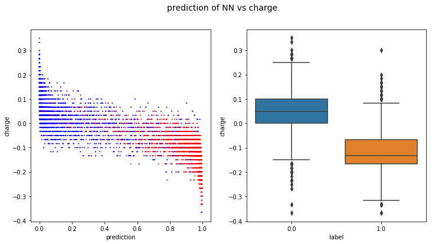

```python
callback = EarlyStopping(patience=1)
# Using a single layer with 3 nodes
K.clear_session()
model = Sequential()
model.add(Dense(units=6, activation='relu', input_shape=(600,)))
model.add(Dense(1, activation='sigmoid'))
model.compile(optimizer='adam', loss='binary_crossentropy', metrics=['accuracy'])
model.fit(deep_classification[0], deep_classification[1],
          epochs=100,
          validation_split=0.1,
          callbacks=[callback],
          verbose=0)

y_hat = model.predict(deep_classification[4]).flatten()

set_of_sequences = []
for i in range(deep_classification[4].shape[0]):
    aminoacids = ''.join([aa[i] for i in deep_classification[4][i].reshape(30,20).argmax(axis=1)])
    set_of_sequences.append(aminoacids)

y = new_data.loc[set_of_sequences].TAD
x = np.array([new_data.loc[i, aa].dot(properties['charge']) for i in set_of_sequences])
cols = ['r' if i==1 else 'b' for i in y]

f, ax = plt.subplots(1,2, figsize=(12,6))
ax[0].scatter(y_hat, x, color=cols, s=1)
ax[0].set_ylabel('charge'); ax[0].set_xlabel('prediction')
plt.suptitle('prediction of NN vs charge', fontsize=14)
sns.boxplot(data=pd.DataFrame(np.vstack([x,y]).T, columns=['charge','label']), x='label', y='charge')

print('rs:      '+str(spearmanr(x,y)[0]))
print('roc_auc: '+str(roc_auc_score(y,x)))
```

Using NN charge still seems to be the dominant factor here. We should find the way to get accross this bias towards negative net charge of a sequence to be considered an activator.

#### Evaluate feature importances in NN models

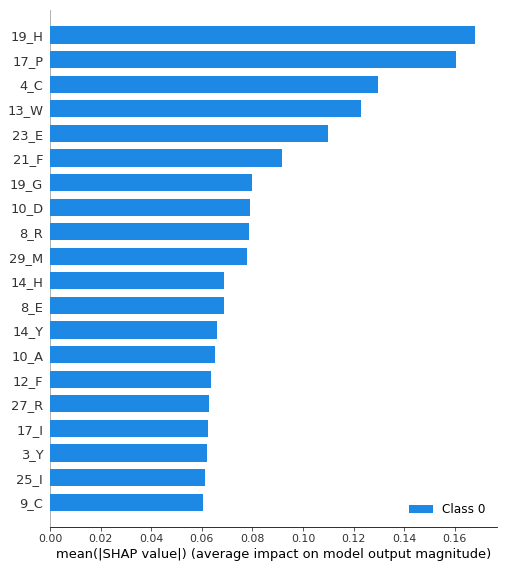

```python
import shap
#shap.initjs()

feature_names = [['_'.join([str(position),aminoacid]) for aminoacid in aa] for position in np.arange(30)]
columns = np.concatenate(feature_names)
Xtrain = pd.DataFrame(deep_classification[0][:10], columns=columns)

explainer = shap.KernelExplainer(model.predict_proba, Xtrain, link="logit")
shap_values = explainer.shap_values(Xtrain, nsamples=100)

shap.summary_plot(shap_values, Xtrain)
#shap.force_plot(explainer.expected_value, shap_values[0], Xtrain)
```

```
Evaluated output channel (0-based index): All
Building gradient functions
Progress: 100.0%
Done.
```

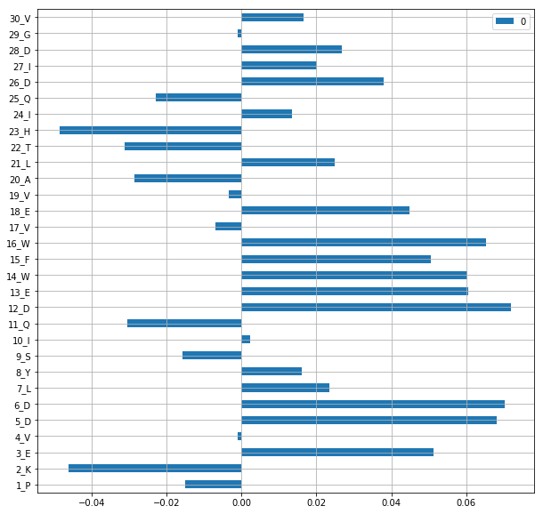

```python
from IntegratedGradients import *

ig = integrated_gradients(model)
grads = ig.explain(deep_classification[4][0])
indx = np.concatenate([['_'.join([str(position),aminoacid]) for aminoacid in aa] for position in np.arange(1,31)])
grads = pd.DataFrame(grads, index=indx)
grads = grads[(grads>0) | (grads<0)].dropna()

grads.plot.barh(figsize=(10,10)); plt.grid()

qPlus = ['R','K','H']
qMinus= ['D','E']
aa_properties = ['']
```

# From here two directions:

1. Go for more complex networks including more features
2. Test if we can see patterns using *shap* and *IntegratedGradients*

#### Dense models including:

- Sequence
- Secondary Structure
- Disorder
- Charge
- Hydrophobicity
- volume

First prepare the data --> **ohe_data** and **labels**

```python
# list of categories of each property
ss = ['-', 'E', 'H']
dis= ['-', 'D']

# prepare dfs. IMPORTANT: these "properties.fasta" contain MUCH more sequences than positive+negative.
# Reduce it to the index that will be used and discard ALL sequences that are not going to be used.
reduced_index, labels = new_data.index, new_data.TAD

# load and get ohe matrices of all secondary structures and disorder
secondary_structure = load_predicted_properties('./30mers_ALL.PSIPRED_ss.fasta')
disorder_long = load_predicted_properties('./30mers_ALL.IUPred_long_disorder.fasta')
disorder_short = load_predicted_properties('./30mers_ALL.IUPred_short_disorder.fasta')

# One hot encode all categorical variables
sequences = np.array([ohe(seq, aa) for seq in reduced_index])
secondary_structure = np.array([ohe(secondary_structure.loc[i], ss) for i in reduced_index])
disorder_long = np.array([ohe(disorder_long.loc[i], dis) for i in reduced_index])
disorder_short = np.array([ohe(disorder_short.loc[i], dis) for i in reduced_index])

# Define which properties we are going to consider here
PROPERTIES = ['volume2', 'hydrophobicity1', 'charge']

# normalize the data into range 0-1 except charge
normalize = lambda x: (x-np.min(x)) / (np.max(x)-np.min(x))
# don't normalize charges, since the sign of numbers contain most of the information.
norm_properties = properties.drop('charge', axis=1).apply(normalize, axis=0)
norm_properties = pd.concat([norm_properties, properties.charge], axis=1)

props = []
for seq in reduced_index:
    tmp = np.vstack([np.array([norm_properties.loc[position, ppt] for position in seq]) for ppt in PROPERTIES]).T
    props.append(tmp)

props = np.array(props)


# combine all variables together, categorical and numerical
ohe_data = np.vstack([sequences.T, secondary_structure.T, disorder_long.T, disorder_short.T, props.T]).T
```

```
./30mers_ALL.PSIPRED_ss.fasta loaded succesfully!
./30mers_ALL.IUPred_long_disorder.fasta loaded succesfully!
./30mers_ALL.IUPred_short_disorder.fasta loaded succesfully!
```

```python
# split 80,10,10
idx = np.arange(ohe_data.shape[0])
np.random.seed=0
np.random.shuffle(idx)

_80, _90 = int(0.8*idx.shape[0]), int(0.9*idx.shape[0])
train, test, valid = idx[:_80], idx[_80:_90], idx[_90:]

# define here the labels and
ytrain, ytest, yvalid = [labels[i] for i in [train, test, valid]]

#define the data flatten for dense network
ohe_flat = ohe_data.reshape(ohe_data.shape[0], 900)
Xtrain_flat, Xtest_flat, Xvalid_flat = [ohe_flat[i] for i in [train, test, valid]]
```

Start with a dense model

```
45it [07:06,  9.48s/it]
```

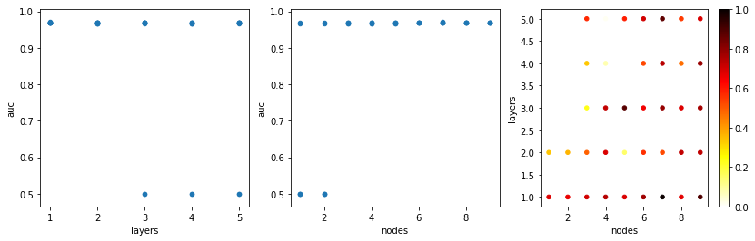

```python
callback = EarlyStopping(patience=1)
num_layers, num_nodes = range(1,6), np.arange(1,10) #5,30,5)

corrs = []

for nlayers, nnodes in tqdm(itertools.product(num_layers, num_nodes)):
    np.random.seed=0

    K.clear_session()
    model = Sequential()
    model.add(Dense(nnodes, activation='relu', input_shape=(900,)))

    for i in range(nlayers-1):
        model.add(Dense(nnodes, activation='relu'))

    model.add(Dense(1, activation='sigmoid'))
    model.compile(optimizer='adam', loss='binary_crossentropy', metrics=['accuracy'])
    model.fit(Xtrain_flat, ytrain,
              epochs=100,
              validation_split=0.1,
              callbacks=[callback],
              verbose=0)

    y_pred = model.predict(Xvalid_flat)
    AUC = roc_auc_score(yvalid, y_pred)
    corrs.append([nlayers, nnodes, model.count_params(), AUC])

corrs = np.array(corrs);
df = pd.DataFrame(corrs, columns=['layers','nodes','parameters','auc']).sort_values('auc', ascending=False)

sz = df.auc.values
m, M = sz[sz>0.5].min(), sz.max()
sz = (sz - m) / (M-m)
sz[sz<0] = 0
# Plot results
f, ax = plt.subplots(1,3, figsize=(14,4))
df.plot.scatter(x='layers', y='auc', ax=ax[0])
df.plot.scatter(x='nodes', y='auc', ax=ax[1])
df.plot.scatter(x='nodes', y='layers', ax=ax[2], c=sz, cmap='hot_r')
```

No significant improvement from the Only sequences  
Convolutional model

```
0.9668211009582545
```

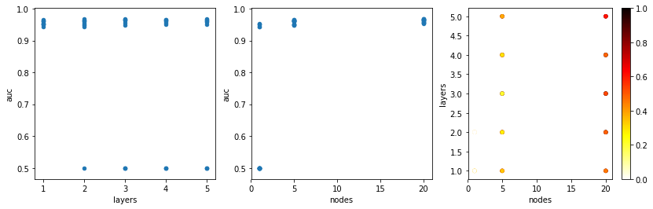

```python
# reshape for convolutions
conv_data = ohe_data.reshape(ohe_data.shape[0], 30,30,1)
Xtrain, Xtest, Xvalid = [conv_data[i] for i in [train, test, valid]]

# choose number of layers and nodes to test
n_layers = np.arange(1,6)
n_nodes = np.array([1,5,20], dtype=int)
n_filters = [2,3,6]
callback = EarlyStopping(patience=1)

corrs = []
for l,n,f in tqdm(itertools.product(n_layers, n_nodes,n_filters)):
    K.clear_session()
    model = Sequential()
    model.add(Conv2D(n, (30, f), activation='relu', input_shape=(30, 30,1), padding='valid'))
    model.add(AveragePooling2D(pool_size=(1, 3), strides=None, padding='valid'))
    model.add(Flatten())
    # add hidden layers
    for layer in range(l-1):
        model.add(Dense(units=n, activation='relu'))
    # output layer
    model.add(Dense(1, activation='sigmoid'))
    # compile
    model.compile(optimizer='adam', loss='binary_crossentropy', metrics=['accuracy'])
    model.fit(Xtrain, ytrain,
              epochs=100,
              validation_split=0.1,
              callbacks=[callback],
              verbose=0)
    # predict and measure performance
    y_hat = model.predict(Xvalid)
    corrs.append([l, n, roc_auc_score(yvalid, y_hat)])

corrs = np.array(corrs);
df = pd.DataFrame(corrs, columns=['layers','nodes','auc']).sort_values('auc', ascending=False)

sz = df.auc.values
m, M = sz[sz>0.5].min(), sz.max()
sz = (sz - m) / (M-m)
sz[sz<0] = 0
# Plot results
f, ax = plt.subplots(1,3, figsize=(14,4))
df.plot.scatter(x='layers', y='auc', ax=ax[0])
df.plot.scatter(x='nodes', y='auc', ax=ax[1])
df.plot.scatter(x='nodes', y='layers', ax=ax[2], c=sz, cmap='hot_r')
print(df.auc.max())`
```

It appears that ONLY Seqeunce performs better than combined with all other features.  
Try sequences, secondary structure and disorder, without volume, hydrophobicity and charge.

```
45it [46:03, 61.40s/it]
```

```
0.9710325849958729
```

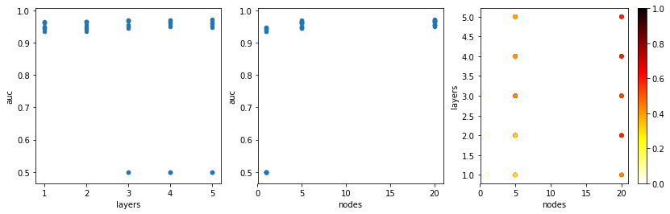

```python
ohe_data = np.vstack([sequences.T, secondary_structure.T, disorder_short.T]).T

# reshape for convolutions
conv_data = ohe_data.reshape(ohe_data.shape[0], 30,25,1)
Xtrain, Xtest, Xvalid = [conv_data[i] for i in [train, test, valid]]

# choose number of layers and nodes to test
n_layers = np.arange(1,6)
n_nodes = np.array([1,5,20], dtype=int)
n_filters = [2,3,6]
callback = EarlyStopping(patience=1)

corrs = []
for l,n,f in tqdm(itertools.product(n_layers, n_nodes,n_filters)):
    K.clear_session()
    model = Sequential()
    model.add(Conv2D(n, (25, f), activation='relu', input_shape=(30, 25,1), padding='valid'))
    model.add(AveragePooling2D(pool_size=(1, 3), strides=None, padding='valid'))
    model.add(Flatten())
    # add hidden layers
    for layer in range(l-1):
        model.add(Dense(units=n, activation='relu'))
    # output layer
    model.add(Dense(1, activation='sigmoid'))
    # compile
    model.compile(optimizer='adam', loss='binary_crossentropy', metrics=['accuracy'])
    model.fit(Xtrain, ytrain,
              epochs=100,
              validation_split=0.1,
              callbacks=[callback],
              verbose=0)
    # predict and measure performance
    y_hat = model.predict(Xvalid)
    corrs.append([l, n, roc_auc_score(yvalid, y_hat)])

corrs = np.array(corrs);
df = pd.DataFrame(corrs, columns=['layers','nodes','auc']).sort_values('auc', ascending=False)

sz = df.auc.values
m, M = sz[sz>0.5].min(), sz.max()
sz = (sz - m) / (M-m)
sz[sz<0] = 0
# Plot results
f, ax = plt.subplots(1,3, figsize=(14,4))
df.plot.scatter(x='layers', y='auc', ax=ax[0])
df.plot.scatter(x='nodes', y='auc', ax=ax[1])
df.plot.scatter(x='nodes', y='layers', ax=ax[2], c=sz, cmap='hot_r')
print(df.auc.max())
```

Same performance as with sequences alone.

# Predictor for Dense model with sequences as the sole input

```python
def describe_prediction(model, protein_name):
    protein = protein_from_sgd(protein_name.upper())
    predictions = predict(model, protein)
    print_prediction(predictions, protein)
    plt.figure(figsize=(20,5))
    plot_prediction(predictions)

# met4, gal4, gcn4, ino2
```

### Gcn4

```
                                                      ******* *                 *           ** *************************
MSEYQPSLFALNPMGFSPLDGSKSTNENVSASTSTAKPMVGQLIFDKFIKTEEDPIIKQDTPSNLDFDFALPQTATAPDAKTVLPIPELDDAVVESFFSSSTDSTPMFEYENLEDNSKEW
***********************    *
TSLFDNDIPVTTDDVSLADKAIESTEEVSLVPSNLEVSTTSFLPTPVLEDAKLTQTRKVKKPNSVVKKSHHVGKDDESRLDHLGVVAYNRKQRSIPLSPIVPESSDPAALKRARNTEAAR

RSRARKLQRMKQLEDKVEELLSKNYHLENEVARLKKLVGER
```

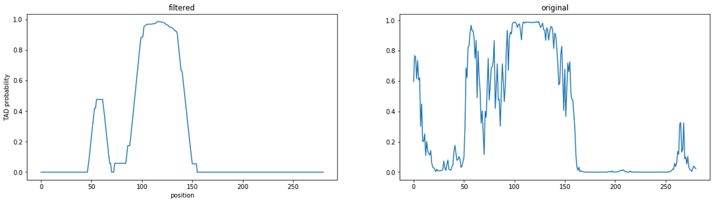

```python
describe_prediction(model, 'gcn4')
```

### Met4

```
    ******                                                                             ******************** *
MKQEQSHEGDSYSTEFINLFGKDTATHPSSNNGANNNGMGSTNSLDQFVATASSSSSLVTSSENRRPLIGDVTNRGNTNLYDHAVTPEILLEQLAYVDNFIPSLDNEFSNVDWNVNTTHN
NANNNGADTFSSINANPFDLDEQLAIELSAFADDSFIFPDEDKPSNNNNNSNNGNDDHSNHDVLHEDPSTNNRQRNPHFLTQRRNTFLTSQYDQSKSRFSSKNKRNGNNGETNNFGDNMQ
                                         *
NNHPFEPNFMGSPSQFPADATNMTSIDHGGFTNVDITSTENNTTGDNGVDALSNLLHRTTHTPNRSSPLSNVTSAQNSSSQQRKHSESKVDSNSDNNSSNKAPNITVPDYSIIPTSVLVT
                                                          *
LLPRVNVPNGAYNSLISAGFDNDQIDAIAAIMAYHHQKKIRENNSNNNKNINTNDSQEAPILKNINELLSVLIPPSPAETAAPTTLSTSPSFNEHGVVAEASFLSSILELGIKHPKSNNI
                                                                                    *** ******************
HNQRQPSRNDHKISRESDGNNGNDNVHHNNAVIKSSTTRGDEIAKIRSEPTLNASSSDHKENSLKRSHSGDLKNKKVPVDRKYSDNEDDEYDDADLHGFEKKQLIKKELGDDDEDLLIQS

KKSHQKKKLKEKELESSIHELTEIAASLQKRIHTLETENKLLKNLVLSSGETEGIKKAESLKKQIFEKVQKE
```

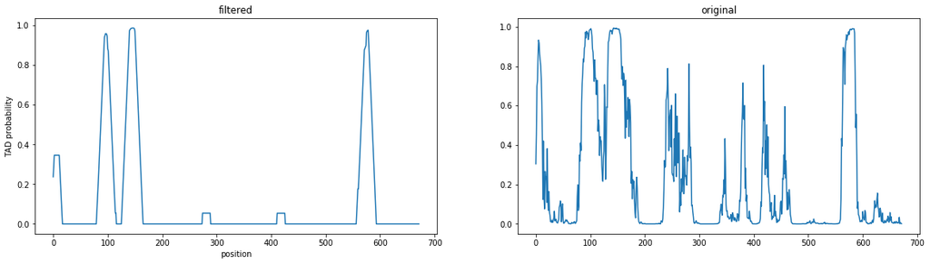

```python
describe_prediction(model, 'met4')
```

### Gal4

```
                                                                 *************** ******* *
MKLLSSIEQACDICRLKKLKCSKEKPKCAKCLKNNWECRYSPKTKRSPLTRAHLTEVESRLERLEQLFLLIFPREDLDMILKMDSLQDIKALLTGLFVQDNVNKDAVTDRLASVETDMPL
                                         *  ******************************  *
TLRQHRISATSSSEESSNKGQRQLTVSIDSAAHHDNSTIPLDFMPRDALHGFDWSEEDDMSDGLPFLKTDPNNNGFFGDGSLLCILRSIGFKPENYTNSNVNRLPTMITDRYTLASRSTT
                                 *** ******* **************
SRLLQSYLNNFHPYCPIVHSPTLMMLYNNQIEIASKDQWQILFNCILAIGAWCIEGESTDIDVFYYQNAKSHLTSKVFESGSIILVTALHLLSRYTQWRQKTNTSYNFHSFSIRMAISLG
                     * *
LNRDLPSSFSDSSILEQRRRIWWSVYSWEIQLSLLYGRSIQLSQNTISFPSSVDDVQRTTTGPTIYHGIIETARLLQVFTKIYELDKTVTAEKSPICAKKCLMICNEIEEVSRQAPKFLQ
                                                                                             * *  **
MDISTTALTNLLKEHPWLSFTRFELKWKQLSLIIYVLRDFFTNFTQKKSQLEQDQNDHQSYEVKRCSIMLSDAAQRTVMSVSSYMDNHNVTPYFAWNCSYYLFNAVLVPIKTLLSNSKSN
                                       *
AENNETAQLLQQINTVLMLLKKLATFKIQTCEKYIQVLEEVCAPFLLSQCAIPLPHISYNNSNGSAIKNIVGSATIAQYPTLPEENVNNISVKYVSPGSVGPSPVPLKSGASFSDLVKLL

SNRPPSRNSPVTIPRSTPSHRSVTPFLGQQQQLQSLVPLTPSALFGGANFNQSGNIADSSLSFTFTNSSNGPNLITTQTNSQALSQPIASSNVHDNFMNNEITASKIDDGNNSKPLSPGW
TDQTAYNAFGITTGMFNTTTMDDVYNYLFDDEDTPPNPKKE
```

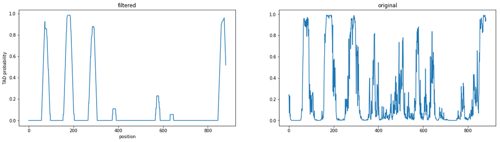

```python
describe_prediction(model, 'gal4')
```

### Ino2

```
MQQATGNELLGILDLDNDIDFETAYQMLSSNFDDQMSAHIHENTFSATSPPLLTHELGIIPNVATVQPSHVETIPADNQTHHAPLHTHAHYLNHNPHQPSMGFDQALGLKLSPSSSGLLS
        *     ** *
TNESNAIEQFLDNLISQDMMSSNASMNSESHLHIRSPKKQHRYTELNQRYPETHPHSNTGELPTNTADVPTEFTTREGPHQPIGNDHYNPPPFSVPEIRIPDSDIPANIEDDPVKVRKWK

HVQMEKIRRINTKEAFERLIKSVRTPPKENGKRIPKHILLTCVMNDIKSIRSANEALQHILDDS
```

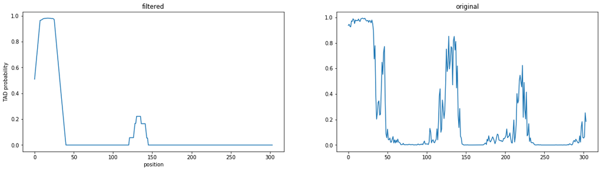

```python
describe_prediction(model, 'Ino2')
```

# Spectrum kernel

```python
%pylab inline
import numpy as np
import pandas as pd
import re,os
```

```python
# read the matrices generated with Noble's script and Keep ONLY digits
positive = pd.read_csv('./positives_matrix.output', delimiter='\t', header=1, index_col=0)
positive = positive.replace(regex=True, to_replace=r'\D',value=r'').astype(float)

negative = pd.read_csv('./negatives_matrix.output', delimiter='\t', header=1, index_col=0);
negative = negative.replace(regex=True, to_replace=r'\D', value=r'').astype(float)

# Add labels
positive['label'] = 1
negative['label'] = 0

# merge into a single df and free some memory space
df = pd.concat([positive, negative], axis=0)
print(df.shape)
print(df.dropna().shape)

del positive
del negative

np.sum(df.sum(axis=0)==0) # borrar las columnas que suman 0 ya que son no-informativas!
```

```python
df = df.dropna()

def split(df):
    #return X,y with:
    #X: list of Xtrain, Xtest and Xvalid
    #y: list of ytrain, ytest and yvalid

    idx = np.arange(df.shape[0])
    np.random.seed=0
    np.random.shuffle(idx)

    _80 = int(0.8*idx.shape[0])
    _90 = int(0.9*idx.shape[0])
    train, test, valid = idx[:_80], idx[_80:_90], idx[_90:]

    X = [df.iloc[i].drop('label', axis=1) for i in [train, test, valid]]
    y = [df.iloc[i].label for i in [train, test, valid]]

    return X, y

# split the data
X,y = split(df)
del(df)
```

#### Are principal components of TADs and non-TADs different?

```
(30079,)
(29993,)
```

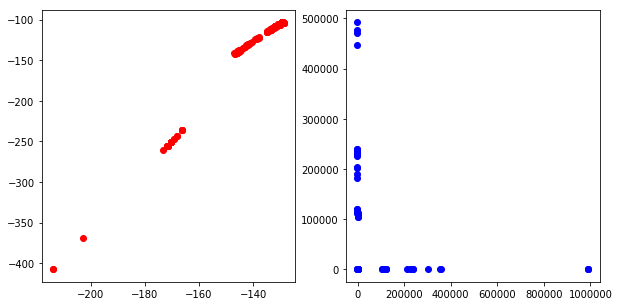

```python
from sklearn.decomposition import PCA

pca = PCA(n_components=2).fit(X[0])
results = pca.transform(X[0])

cols = ['r' if i==1 else 'b' for i in y[0]]
posit = np.where(y[0]==1)
negat = np.where(y[0]==0)

print(posit[0].shape)
print(negat[0].shape)

plt.figure(figsize=(10,5))
plt.subplot(121)
plt.scatter(results[posit,0], results[posit,1], c='r')
plt.subplot(122)
plt.scatter(results[negat,0], results[negat,1], c='b');
```

Scales are deffinitely different

Test the spectrum kernel with svm. To make the svm converge during my lifetime, first cluster the data and use these clusters as features for the svm)

```python
from sklearn.cluster import MiniBatchKMeans
inertias = []
for c in range(2,7):
    km = MiniBatchKMeans(n_clusters=c, random_state=0).fit(X[0])
    inertias.append(km.inertia_)

plt.plot(np.arange(1,4), inertias)
```

another approach

```python
from sklearn.mixture import GaussianMixture
#gmm = GaussianMixture().fit(X[0])
#proba = gmm.predict_proba(X[0])
#svm = SVC().fit(proba,y)

from sklearn.cluster import KMeans
inertias = []
for c in range(1,20):
    km = KMeans(n_clusters=c, random_state=0).fit(X[0])
    inertias.append(km.inertia_)

plt.plot(np.arange(1,20), inertias)

# use centroids as features
```

```python
model_json = model.to_json()
f = open('Dense_1_6nodes_sequences.json', 'w')
f.write(model_json)
f.close()
model.save_weights('Dense_1_6nodes_sequences.h5')
```

```python
from keras.models import model_from_json

model_json = open('./Dense_1_6nodes_sequences.json', 'r')
loaded_model_json = model_json.read()
model_json.close()
model = model_from_json(loaded_model_json)


model.load_weights('Dense_1_6nodes_sequences.h5')
model.compile(loss='binary_crossentropy', optimizer='adam', metrics=['accuracy'])
print(model.summary())
```

```
_________________________________________________________________
Layer (type)                 Output Shape              Param #
=================================================================
dense_1 (Dense)              (None, 6)                 3606
_________________________________________________________________
dense_2 (Dense)              (None, 1)                 7
=================================================================
Total params: 3,613
Trainable params: 3,613
Non-trainable params: 0
_________________________________________________________________
None
```